# Intro to R

# R Basics

## Data Types

- A **value** is a basic unit of stuff that a program works with.
- Values are allowed to have different *data types*:
1. **logical / boolean**: FALSE / TRUE or 0 / 1 values.
2. **integer**: whole numbers.
3. **double / float / numeric**: decimal numbers.
4. **character / string** - text values.

## Variables

> are names that refer to values.
- A variable is like a container that holds something - when you refer to the container, you get whatever is stored inside.
- We assign values to variables using the syntax `object_name <- value`.
  - This can be read as “object name gets value.”

```r
message <- "So long and thanks for all the fish"
year <- 2025
the_answer <- 42.5
earth_demolished <- FALSE
```

## Data Structures

- Homogeneous
- Heterogeneous

> every element has the same data type
- **Vector**: a one-dimensional column of homogeneous data.
- **Matrix**: the next step after a vector - it’s a set of homogenous data arranged in a two-dimensional, rectangular format.

> elements can be of different types
- **List**: a one-dimensional column of heterogeneous data.
- **Dataframe**: a two-dimensional set of heterogeneous data arranged in a rectangular format.

## Indexing

We use **square brackets** (`[]`) to access elements within data structures.

- In R, we start indexing from 1.
- Vector
- Matrix
- List
- Dataframe

```r
vec[4]    # 4th element
vec[1:3]  # first 3 elements
```

```r
mat[2, 6]  # element in row 2, col 6
mat[ , 3]   # all elements in col 3
```

```r
li[[5]]    # 5th element
li$elementName # all elements in "elementName"
```

```r
df[1, 2]     # element in row 1, col 2
df[17, ]     # all elements in row 17
df$colName  # all elements in the col named "colName"
```

## Logic

We can combine logical statements using and, or, and not.

- (X AND Y) requires that **both** X and Y are true.
- (X OR Y) requires that **one** of X or Y is true.
- (NOT X) is true if X is false, and false if X is true.

```r
x <- c(TRUE, FALSE, TRUE, FALSE)
y <- c(TRUE, TRUE, FALSE, FALSE)
```

- And
- Or
- Not

```r
x & y
```

```
[1]  TRUE FALSE FALSE FALSE
```

```r
x | y
```

```
[1]  TRUE  TRUE  TRUE FALSE
```

```r
!x
```

```
[1] FALSE  TRUE FALSE  TRUE
```

# Syntax Errors

## Did you leave off a parenthesis?

seq(from = 1, to = 10, by = 1

```r
seq(from = 1, to = 10, by = 1
```

```
Error in parse(text = input): <text>:2:0: unexpected end of input
1: seq(from = 1, to = 10, by = 1
   ^
```

```r
seq(from = 1, to = 10, by = 1)
```

```
 [1]  1  2  3  4  5  6  7  8  9 10
```

## Did you leave off a comma?

seq(from = 1, to = 10 by = 1)

```r
seq(from = 1, to = 10 by = 1)
```

```
Error in parse(text = input): <text>:1:23: unexpected symbol
1: seq(from = 1, to = 10 by
                          ^
```

```r
seq(from = 1, to = 10, by = 1)
```

```
 [1]  1  2  3  4  5  6  7  8  9 10
```

## Are you using the right function name?

sequence(from = 1, to = 10, by = 1)

```r
sequence(from = 1, to = 10, by = 1)
```

```
Error in `sequence.default()`:
! argument "nvec" is missing, with no default
```

```r
seq(from = 1, to = 10, by = 1)
```

```
 [1]  1  2  3  4  5  6  7  8  9 10
```

# Object Type Errors

## Are you using the right *input* that the function expects?

sqrt(“1”)

```r
sqrt("1")
```

```
Error in `sqrt()`:
! non-numeric argument to mathematical function
```

```r
sqrt(1)
```

```
[1] 1
```

## Are you expecting the right *output* of the function?

my_obj(5)

```r
my_obj <- seq(from = 1, to = 10, by = 1)

my_obj(5)
```

```
Error in `my_obj()`:
! could not find function "my_obj"
```

```r
my_obj[5]
```

```
[1] 5
```

# Errors + Warnings + Messages

## Messages

Just because you see scary red text, this does **not** mean something went wrong! This is just R communicating with you.

For example, you will often see:

```r
library(lme4)
```

[output not shown]

## Warnings

Often, R will give you a **warning**.

- This means that your code *did* run…
- …but you probably want to make sure it succeeded.

```r
my_vec <- c("a", "b", "c")

my_new_vec <- as.integer(my_vec)
```

```
Warning: NAs introduced by coercion
```

**Does this look right?**

```r
my_new_vec
```

```
[1] NA NA NA
```

## Errors

If the word **Error** appears in your message from R, then you have a problem.

This means your code **could not run**!

```r
my_vec <- c("a", "b", "c")

my_new_vec <- my_vec + 1
```

```
Error in `my_vec + 1`:
! non-numeric argument to binary operator
```

# Parlez-vous ERROR?

## **R** says…

> Error: Object `some_obj` not found.

It *probably* means…

> You haven’t run the code to create `some_obj` OR you have a typo in the name!

```r
some_ojb <- 1:10

mean(some_obj)
```

```
Error in `h()`:
! error in evaluating the argument 'x' in selecting a method for function 'mean': object 'some_obj' not found
```

## **R** says…

> Error: Object of type ‘closure’ is not subsettable.

It *probably* means…

> Oops, you tried to use square brackets on a function.

```r
mean[1, 2]
```

```
Error in `mean[1, 2]`:
! object of type 'closure' is not subsettable
```

## **R** says…

> Error: Non-numeric argument to binary operator.

It *probably* means…

> You tried to do math on data that isn’t numeric.

```r
"a" + 2
```

```
Error in `"a" + 2`:
! non-numeric argument to binary operator
```

## What if none of these solved my error?

1. Look at the help file for the function! (e.g., `?group_by`)
2. When all else fails, Google your error message or ask ChatGPT!
- Leave out the specifics.
- Include the name(s) of the function(s) you are using.

## Try it…

**What’s wrong here?**

```r
matrix(
  c("a", "b", "c", "d"),
  num_row = 2
  )
```

```
Error in `matrix()`:
! unused argument (num_row = 2)
```

The documentation says…

```
matrix(data = NA, nrow = 1, ncol = 1, byrow = FALSE,
       dimnames = NULL)
```

# Scripts + Notebooks

## Scripts

- **Scripts** (`File > New File > R Script`) are files of code that are meant to be run on their own.
- Scripts can be run in RStudio by clicking the `Run` button at the top of the editor window when the script is open.
- You can also run code interactively in a script by:
  - highlighting lines of code and hitting run.
  - placing your cursor on a line of code and hitting run.
  - placing your cursor on a line of code and hitting `ctrl + enter` or `command + enter`.

## Notebooks

Notebooks are an implementation of **literate programming**.

- They allow you to integrate code, output, text, images, etc. into a single document.
- E.g.,
  - **Quarto notebook**
  - R Markdown notebook
  - Jupyter notebook

We love notebooks because they help us produce a reproducible analysis!

## What is Markdown?

**Markdown** is a *markup language*.

It uses special symbols and formatting to make pretty documents.

- *italics* – makes italics
- **bold** – makes bold text
- # – makes headers
- ! – includes images or HTML links
- < > – embeds URLs

Markdown files have the **.md** extension.

## What is Quarto?

Quarto **unifies** and **extends** the R Markdown ecosystem.

[figure not shown]

Quarto files have the **.qmd** extension.

## Highlights of Quarto

- Consistent implementation of attractive and handy features across outputs:
  - E.g., tabsets, code-folding, syntax highlighting, etc.
- More accessible defaults and better support for accessibility.
- Guardrails that are helpful when learning:
  - E.g., YAML completion, informative syntax errors, etc.
- Support for other languages like Python, Julia, Observable, and more.

## Quarto Formats

Quarto makes moving between outputs straightforward.

- All that needs to change between these formats is a few lines in the front matter (YAML)!

**Document**

```yaml
title: "Lesson 1"
format: html
```

**Presentation**

```yaml
title: "Lesson 1"
format: revealjs
```

**Website**

```yaml
project:
  type: website

website:
  navbar:
    left:
      - lesson-1.qmd
```

## Quarto Components

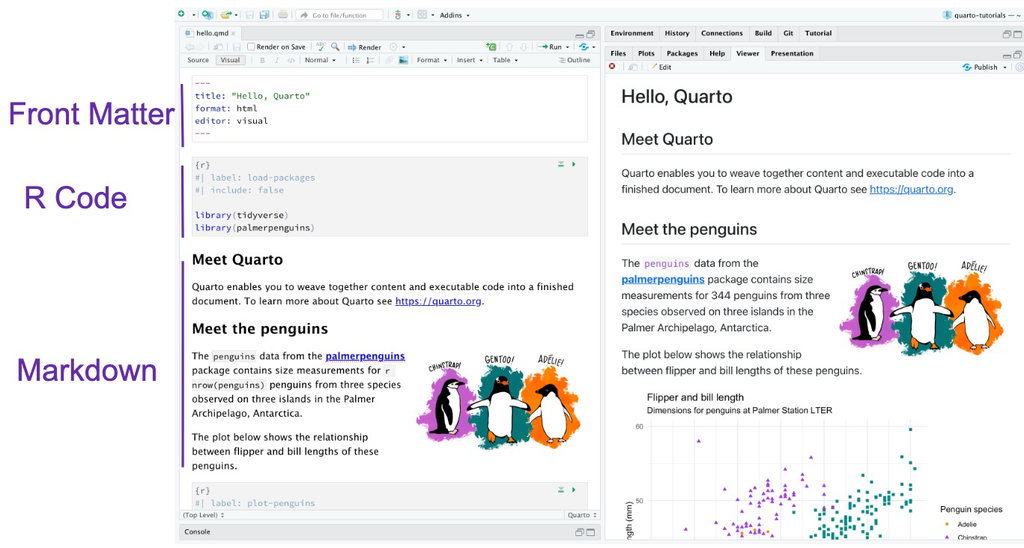

**How does Quarto know that a section of text should be interpreted as R code?**

## R Code Options in Quarto

**R code chunk** options are included at the top of each code chunk, prefaced with a `#|` (hashpipe).

- These options control how the following code is run and reported in the final Quarto document.
- Some R code options can also be included in the front matter (YAML) which would be applied globally to the entire document.

## R Code Options in Quarto

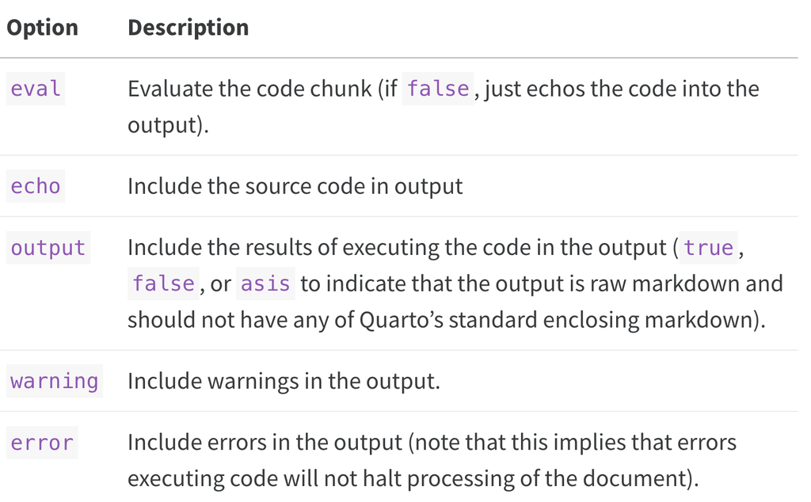

## Chunk Option Completion in Quarto

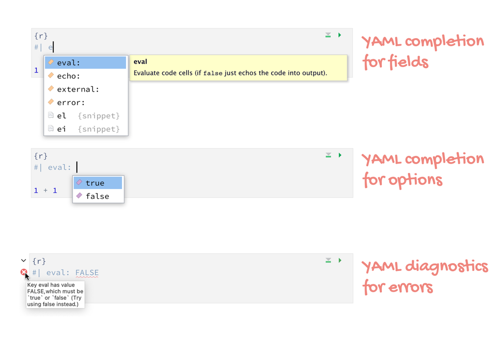

## Rendering your Quarto Document

To take your *.qmd* file and make it look pretty, you have to **render** it.

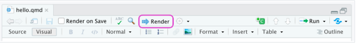

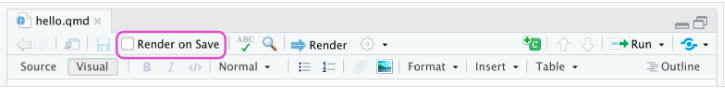

## Rendering your Quarto Document

Quarto CLI (command line interface) orchestrates each step of rendering:

1. Process the executable code chunks with either `knitr` or `jupyter`.
2. Convert the resulting Markdown file to the desired output.

[figure not shown]

## Rendering your Quarto Document

When you click **Render**:

1. Your file is saved.
2. The R code written in your *.qmd* file gets run **in order**.
- It starts from scratch, even if you previously ran some of the code in RStudio.
3. A new file is created.
- If your Quarto file is called “Lab1.qmd”, then a file called “Lab1.html” will be created.
- This will be saved in the same folder as “Lab1.qmd”.